# Regression with R: Extract, Tabulate, Plot

Econ 440 - Introduction to Econometrics

Patrick Toche, ptoche@fullerton.edu

10 May 2022

# Extract, Tabulate, Plot

In this notebook we explore how to extract regression coefficients, standard errors, p-values and other pieces of information contained in a linear regression model. We also learn how to augment a regression model, how to tabulate regression results, and how to plot regression lines.

## Dataset on Earnings

The data file **CPS2015** contains data for full-time, full-year workers, ages 25–34, with a high school diploma or B.A./B.S. as their highest degree. A detailed description is given in **CPS2015_Description**.

```r
library(readxl)
df <- read_xlsx("CPS2015.xlsx", trim_ws=TRUE)
head(df)
```

```
## # A tibble: 6 × 5
##    year   ahe bachelor female   age
##   <dbl> <dbl>    <dbl>  <dbl> <dbl>
## 1  2015 11.8         0      0    26
## 2  2015  9.62        0      1    33
## 3  2015 12.0         0      0    31
## 4  2015 18.4         0      0    32
## 5  2015 41.8         0      0    28
## 6  2015 19.2         0      1    31
```

## A Log-quadratic model

This nonlinear regression model is analyzed in Chapter 8 of Stock and Watson’s **Introduction to Econometrics**. Run a linear model with $lm()$ to produce a model object, then call the $summary()$ function to extract basic information.

```r
m1 <- lm(log(ahe) ~ age + I(age^2) + bachelor + female, data=df)
summary(m1)
```

```
##
## Call:
## lm(formula = log(ahe) ~ age + I(age^2) + bachelor + female, data = df)
##
## Residuals:
##     Min      1Q  Median      3Q     Max
## -2.5764 -0.2868  0.0126  0.3041  2.0596
##
## Coefficients:
##              Estimate Std. Error t value Pr(>|t|)
## (Intercept)  0.418745   0.672088    0.62   0.5333
## age          0.134115   0.045791    2.93   0.0034 **
## I(age^2)    -0.001860   0.000774   -2.40   0.0163 *
## bachelor     0.461629   0.011473   40.24   <2e-16 ***
## female      -0.177364   0.011626  -15.26   <2e-16 ***
## ---
## Signif. codes:  0 '***' 0.001 '**' 0.01 '*' 0.05 '.' 0.1 ' ' 1
##
## Residual standard error: 0.477 on 7093 degrees of freedom
## Multiple R-squared:  0.209,  Adjusted R-squared:  0.209
## F-statistic:  469 on 4 and 7093 DF,  p-value: <2e-16
```

## Look inside a model object

See inside the model object: a list that holds useful results obtained from the regression, including the estimates, residuals, and standard errors.

```r
str(m1)
```

```
## List of 12
##  $ coefficients : Named num [1:5] 0.41874 0.13412 -0.00186 0.46163 -0.17736
##   ..- attr(*, "names")= chr [1:5] "(Intercept)" "age" "I(age^2)" "bachelor" ...
##  $ residuals    : Named num [1:7098] -0.182 -0.378 -0.302 0.106 1.018 ...
##   ..- attr(*, "names")= chr [1:7098] "1" "2" "3" "4" ...
##  $ effects      : Named num [1:7098] -245.4 -6.08 -1.1 18.32 -7.28 ...
##   ..- attr(*, "names")= chr [1:7098] "(Intercept)" "age" "I(age^2)" "bachelor" ...
##  $ rank         : int 5
##  $ fitted.values: Named num [1:7098] 2.65 2.64 2.79 2.81 2.72 ...
##   ..- attr(*, "names")= chr [1:7098] "1" "2" "3" "4" ...
##  $ assign       : int [1:5] 0 1 2 3 4
##  $ qr           :List of 5
##   ..$ qr   : num [1:7098, 1:5] -84.2496 0.0119 0.0119 0.0119 0.0119 ...
##   .. ..- attr(*, "dimnames")=List of 2
##   .. .. ..$ : chr [1:7098] "1" "2" "3" "4" ...
##   .. .. ..$ : chr [1:5] "(Intercept)" "age" "I(age^2)" "bachelor" ...
##   .. ..- attr(*, "assign")= int [1:5] 0 1 2 3 4
##   ..$ qraux: num [1:5] 1.01 1.01 1.01 1.01 1.01
##   ..$ pivot: int [1:5] 1 2 3 4 5
##   ..$ tol  : num 1e-07
##   ..$ rank : int 5
##   ..- attr(*, "class")= chr "qr"
##  $ df.residual  : int 7093
##  $ xlevels      : Named list()
##  $ call         : language lm(formula = log(ahe) ~ age + I(age^2) + bachelor + female, data = df)
##  $ terms        :Classes 'terms', 'formula'  language log(ahe) ~ age + I(age^2) + bachelor + female
##   .. ..- attr(*, "variables")= language list(log(ahe), age, I(age^2), bachelor, female)
##   .. ..- attr(*, "factors")= int [1:5, 1:4] 0 1 0 0 0 0 0 1 0 0 ...
##   .. .. ..- attr(*, "dimnames")=List of 2
##   .. .. .. ..$ : chr [1:5] "log(ahe)" "age" "I(age^2)" "bachelor" ...
##   .. .. .. ..$ : chr [1:4] "age" "I(age^2)" "bachelor" "female"
##   .. ..- attr(*, "term.labels")= chr [1:4] "age" "I(age^2)" "bachelor" "female"
##   .. ..- attr(*, "order")= int [1:4] 1 1 1 1
##   .. ..- attr(*, "intercept")= int 1
##   .. ..- attr(*, "response")= int 1
##   .. ..- attr(*, ".Environment")=<environment: R_GlobalEnv>
##   .. ..- attr(*, "predvars")= language list(log(ahe), age, I(age^2), bachelor, female)
##   .. ..- attr(*, "dataClasses")= Named chr [1:5] "numeric" "numeric" "numeric" "numeric" ...
##   .. .. ..- attr(*, "names")= chr [1:5] "log(ahe)" "age" "I(age^2)" "bachelor" ...
##  $ model        :'data.frame':   7098 obs. of  5 variables:
##   ..$ log(ahe): num [1:7098] 2.47 2.26 2.49 2.91 3.73 ...
##   ..$ age     : num [1:7098] 26 33 31 32 28 31 34 33 34 33 ...
##   ..$ I(age^2): 'AsIs' num [1:7098]  676 1089  961 1024  784 ...
##   ..$ bachelor: num [1:7098] 0 0 0 0 0 0 0 1 0 1 ...
##   ..$ female  : num [1:7098] 0 1 0 0 0 1 0 1 0 1 ...
##   ..- attr(*, "terms")=Classes 'terms', 'formula'  language log(ahe) ~ age + I(age^2) + bachelor + female
##   .. .. ..- attr(*, "variables")= language list(log(ahe), age, I(age^2), bachelor, female)
##   .. .. ..- attr(*, "factors")= int [1:5, 1:4] 0 1 0 0 0 0 0 1 0 0 ...
##   .. .. .. ..- attr(*, "dimnames")=List of 2
##   .. .. .. .. ..$ : chr [1:5] "log(ahe)" "age" "I(age^2)" "bachelor" ...
##   .. .. .. .. ..$ : chr [1:4] "age" "I(age^2)" "bachelor" "female"
##   .. .. ..- attr(*, "term.labels")= chr [1:4] "age" "I(age^2)" "bachelor" "female"
##   .. .. ..- attr(*, "order")= int [1:4] 1 1 1 1
##   .. .. ..- attr(*, "intercept")= int 1
##   .. .. ..- attr(*, "response")= int 1
##   .. .. ..- attr(*, ".Environment")=<environment: R_GlobalEnv>
##   .. .. ..- attr(*, "predvars")= language list(log(ahe), age, I(age^2), bachelor, female)
##   .. .. ..- attr(*, "dataClasses")= Named chr [1:5] "numeric" "numeric" "numeric" "numeric" ...
##   .. .. .. ..- attr(*, "names")= chr [1:5] "log(ahe)" "age" "I(age^2)" "bachelor" ...
##  - attr(*, "class")= chr "lm"
```

You may save the coefficients to a list:

```r
coefs <- coef(m1)
names(coefs)
```

```
## [1] "(Intercept)" "age"         "I(age^2)"    "bachelor"    "female"
```

You may extract the coefficients by name:

```r
coefs["(Intercept)"]
```

```
## (Intercept)
##     0.41874
```

```r
coefs["bachelor"]
```

```
## bachelor
##  0.46163
```

Beware: In strings, spaces and cases matter, so the following won’t work!

```r
coefs["(intercept)"]
```

```
## <NA>
##   NA
```

The $broom$ package offers a more convenient and more versatile interface to extract and transform the regression data.

## Explore the model object with broom

The $broom$ package provides convenience functions, including $tidy()$, $glance()$ and $augment()$. These functions always return a `tibble` (a modern dataframe).

Extract coefficients: $tidy()$ returns a nicely formatted dataframe:

```r
tidy(m1)
```

```
## # A tibble: 5 × 5
##   term        estimate std.error statistic   p.value
##   <chr>          <dbl>     <dbl>     <dbl>     <dbl>
## 1 (Intercept)  0.419    0.672        0.623 5.33e-  1
## 2 age          0.134    0.0458       2.93  3.41e-  3
## 3 I(age^2)    -0.00186  0.000774    -2.40  1.63e-  2
## 4 bachelor     0.462    0.0115      40.2   4.95e-319
## 5 female      -0.177    0.0116     -15.3   9.83e- 52
```

Same with pipe operator and a slice to select a coefficient of interest. The function $pull()$ is then used to extract the desired value, e.g. $pull(std.error)$. The result can be manipulated further, e.g. rounding:

```r
m1 %>% tidy() %>% slice(2) %>% pull(std.error) %>% round(.,3)
```

```
## [1] 0.046
```

You can add confidence intervals with the $conf.int$ argument and extract the desired values with $pull()$:

```r
m1 %>% tidy(conf.int=TRUE, conf.level=0.80) %>% pull(conf.low)
```

```
## [1] -0.4426506  0.0754267 -0.0028526  0.4469246 -0.1922645
```

The $augment()$ function can be used to extract the fitted values and residuals for the original observations. In the augmented dataframe/tibble, each of the new columns begins with a dot, e.g. `.fitted`, to avoid accidentally overwriting existing variable names. This data could be extracted and used to plot a regression line and confidence interval, for instance.

```r
ma <- augment(m1, data=df)
names(ma)
```

```
##  [1] "year"       "ahe"        "bachelor"   "female"     "age"
##  [6] ".fitted"    ".resid"     ".hat"       ".sigma"     ".cooksd"
## [11] ".std.resid"
```

The $glance()$ function can be used to extract summary statistics for the entire regression, including the R-squared and the F-statistic.

```r
mg <- glance(m1, data=df)
names(mg)  # glancing the regression statistics
```

```
##  [1] "r.squared"     "adj.r.squared" "sigma"         "statistic"
##  [5] "p.value"       "df"            "logLik"        "AIC"
##  [9] "BIC"           "deviance"      "df.residual"   "nobs"
```

For instance, the R-squared can be extracted with:

```r
R2 <- mg$r.squared  # or mg[["r.squared"]]
print(R2)
```

```
## [1] 0.20901
```

## Visualize the regression coefficients

The following plot allows you to quickly visualize the regression coefficients:

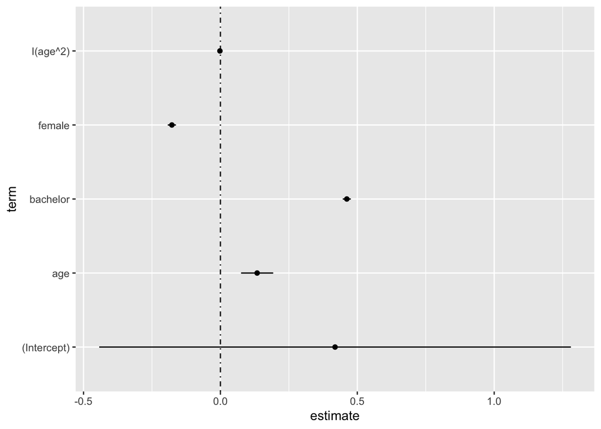

```r
m1 %>% tidy(conf.int=TRUE, conf.level=0.80)  %>%
  ggplot(., aes(estimate, term, xmin=conf.low, xmax=conf.high, height=0)) +
  geom_point() +
  geom_vline(xintercept=0, lty=4) +
  geom_errorbarh()
```

# Plot regression lines

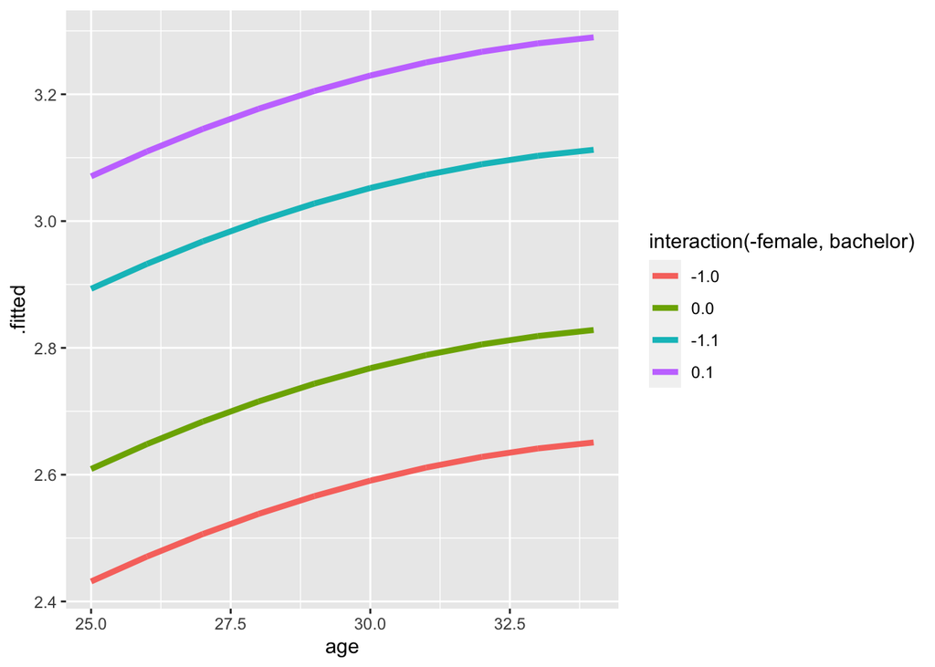

```r
augment(m1, df, interval="confidence") %>%
  ggplot(data=.) +
  aes(x=age,
      y=.fitted,
      group=interaction(-female, bachelor),
      color=interaction(-female, bachelor)) +
    geom_line(size=1.5) -> p0
p0
```

## Fix the legend, select colors, tweak labels

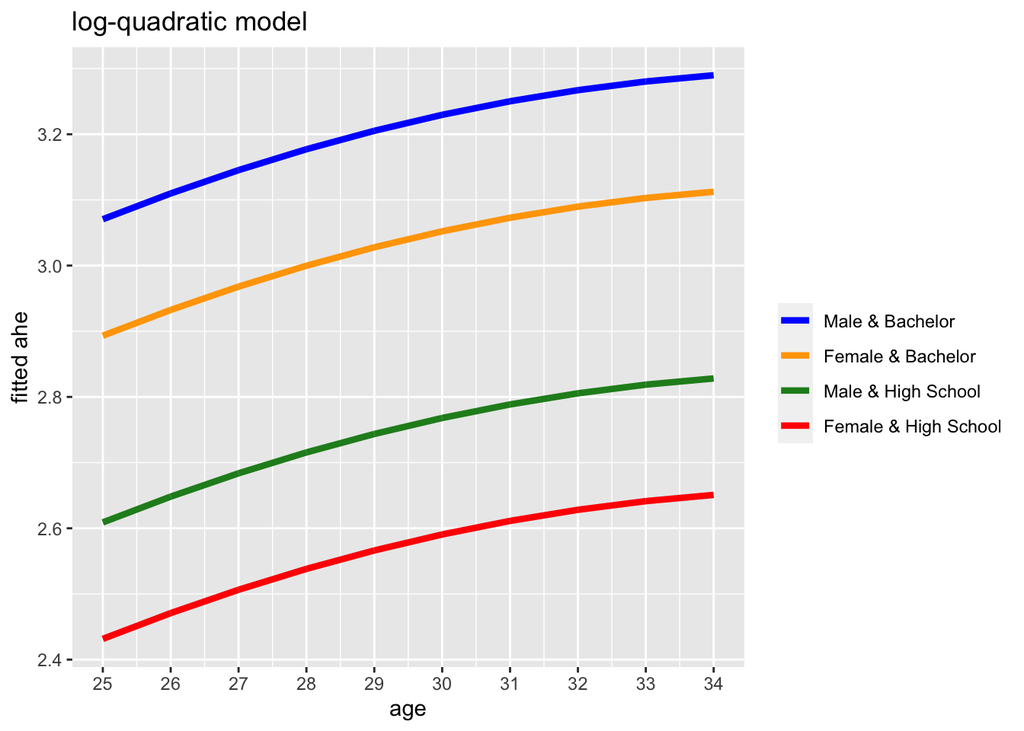

```r
labs <- c("Female & High School", "Male & High School", "Female & Bachelor", "Male & Bachelor")  # create labels
p0 + scale_x_continuous(breaks=seq(25,35,1)) +
  scale_color_manual(name="",labels=labs, values=c("red", "forestgreen", "orange", "blue")) +
  guides(color=guide_legend(reverse=TRUE)) +
  ylab("fitted ahe") +
  ggtitle("log-quadratic model") -> p1
p1
```

## Add confidence intervals

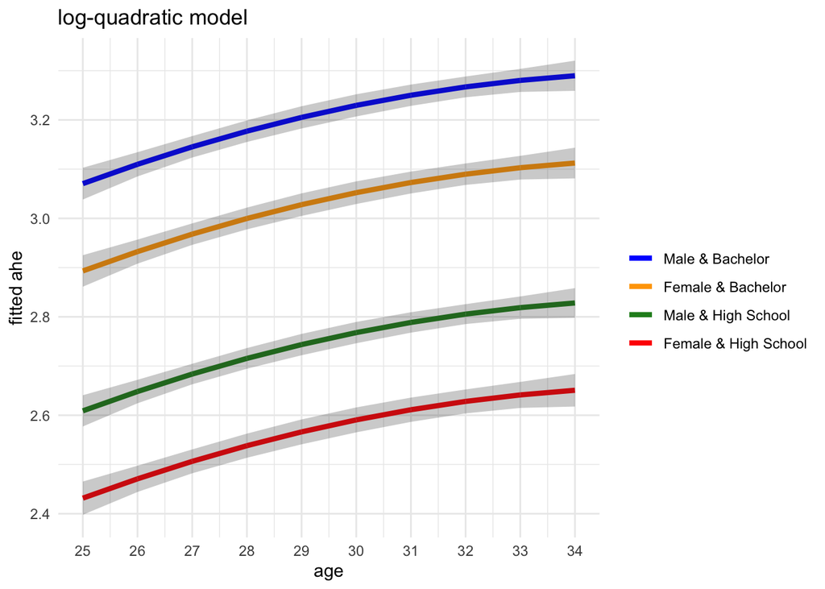

```r
p1 + geom_ribbon(aes(ymin=.lower, ymax=.upper), alpha=.25, color=NA) -> p2
p2 + theme_minimal()
```

## Add theme to the plot

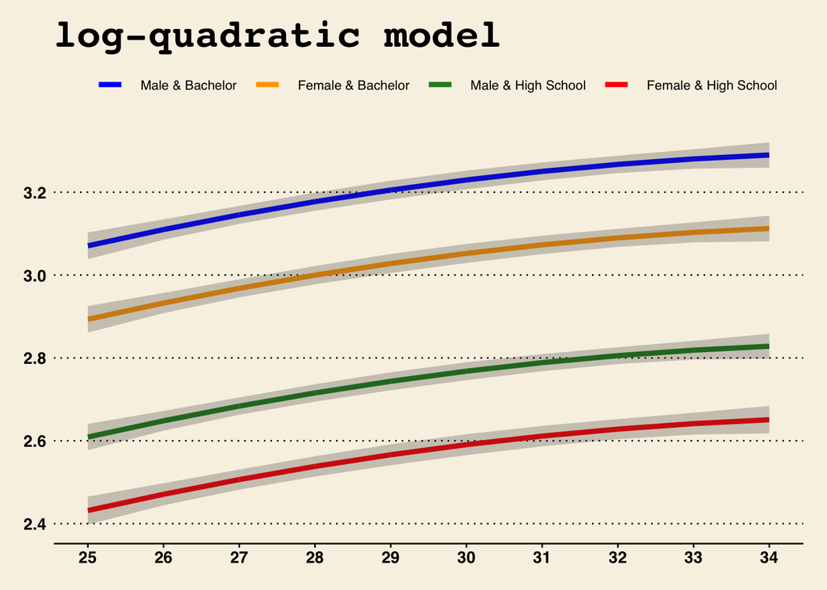

```r
library(ggthemes)  # to theme the plot
p2 + theme_wsj(base_size=10)
```

## Confidence Intervals for Parameters

The `dplyr` package (part of `tidyverse`) contains a convenient $full_join()$ function that may be used to merge dataframes containing estimates calculated with `broom` functions like $tidy()$ and $glance()$. First, create a dataframe which contains both the data estimates (using $tidy()$) and the model’s summary statistics (using $glance()$). Then use $pull()$ to get the desired statistics.

```r
dplyr::full_join(
  df %>% group_modify(.f = ~ tidy(m1, conf.int=TRUE, conf.level=0.99)),
  df %>% group_modify(.f = ~ glance(m1))
) -> dm
```

Then pull the desired statistics:

```r
dm %>% pull(estimate)
```

```
## [1]  0.4187449  0.1341152 -0.0018603  0.4616293 -0.1773644         NA
```

```r
dm %>% pull(conf.low)
```

```
## [1] -1.3129048  0.0161346 -0.0038551  0.4320687 -0.2073179         NA
```

```r
dm %>% pull(conf.high)
```

```
## [1]  2.15039470  0.25209570  0.00013449  0.49118990 -0.14741083          NA
```

## Multiple models

Let’s compute several regression models.

```r
m2 <- lm(log(ahe) ~ age + I(age^2) + I(age^3) + bachelor + female, data=df)
m3 <- lm(log(ahe) ~ log(age) + bachelor + female, data=df)
```

## Fitted values and residuals

Clusters of points can potentially cause the errors to be heteroskedastic. To visualize this, we color the points according to the four combinations of Male/Female and Bachelor/High-School. We suppress the legend for clarity and set the color palette with the $scale_color_brewer()$ function of the `ggplot2` package.

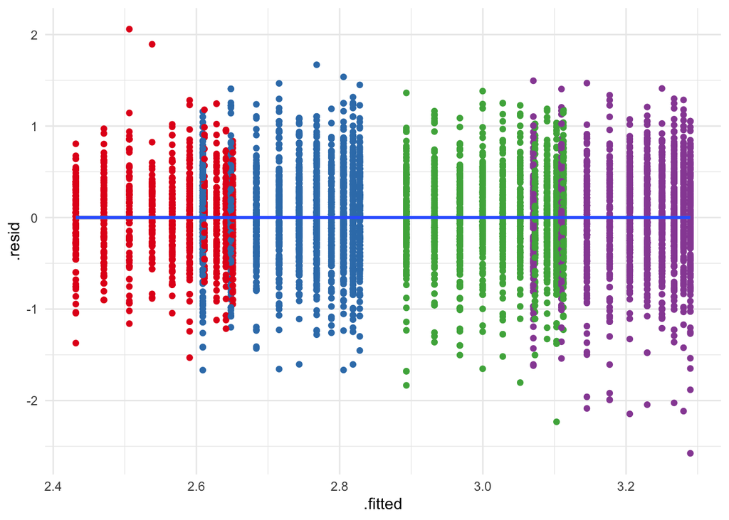

```r
augment(m1, df, interval="confidence") %>%
  ggplot(data=., aes(x=.fitted, y=.resid)) +
  geom_point(aes(color=interaction(-female, bachelor))) +
  geom_smooth(method="lm") +
  scale_color_brewer(palette="Set1") +
  theme_minimal() +
  theme(legend.position="none")
```

Look at the distribution of the residuals for evidence of heteroskedasticity:

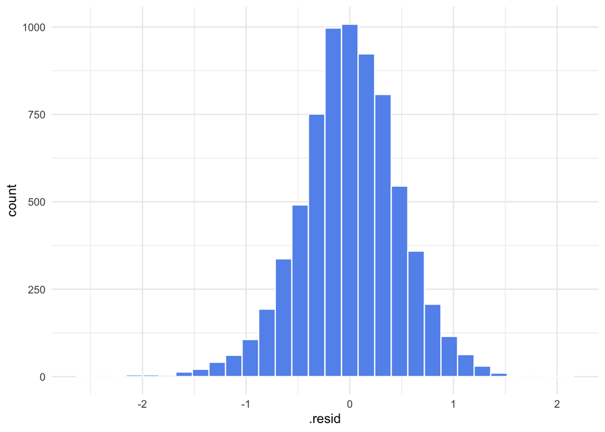

```r
augment(m1, df, interval="confidence") %>%
  ggplot(data=., aes(x=.resid)) +
  geom_histogram(color="white", fill="cornflowerblue") +
  theme_minimal()
```

## Compute robust standard errors

The `sandwich` package computes robust Heteroscedasticity-Consistent Covariance estimators with the function $vcovHC()$. The $type$ argument can be used to specify estimators from $HC0$ (White’s estimator) to $HC5$ (various refinements). The `lmtest` package provides a convenient function, $coeftest()$, to calculate the t test based on the variance-covariance matrix provided in the $vcov$ argument. A robust test may be computed as follows:

```r
library(sandwich)
library(lmtest)  # coeftest, waldtest
coeftest(m1, vcov=vcovHC(m1, type="HC1"))
```

```
##
## t test of coefficients:
##
##              Estimate Std. Error t value Pr(>|t|)
## (Intercept)  0.418745   0.669575    0.63   0.5317
## age          0.134115   0.045610    2.94   0.0033 **
## I(age^2)    -0.001860   0.000771   -2.41   0.0159 *
## bachelor     0.461629   0.011456   40.30   <2e-16 ***
## female      -0.177364   0.011499  -15.42   <2e-16 ***
## ---
## Signif. codes:  0 '***' 0.001 '**' 0.01 '*' 0.05 '.' 0.1 ' ' 1
```

## Compute robust Wald test

A heteroskedasticity robust F test may be calculated with the $waldtest$ function from package $lmtest$ (using White standard errors):

```r
m1.unrestricted <- lm(log(ahe) ~ age + I(age^2) + I(age^3) + bachelor + female, data=df)
waldtest(m1, m1.unrestricted, vcov=vcovHC(m1.unrestricted, type="HC0"))
```

```
## Wald test
##
## Model 1: log(ahe) ~ age + I(age^2) + bachelor + female
## Model 2: log(ahe) ~ age + I(age^2) + I(age^3) + bachelor + female
##   Res.Df Df    F Pr(>F)
## 1   7093
## 2   7092  1 0.03   0.85
```

# Tabulate Regression results

Tabulating regression results may be automated with the help of several packages. A popular solution is `stargazer`. Here instead I use a newer package, `texreg`.

## Output the table to screen with $screenreg()$:

```r
suppressMessages(library(texreg))
screenreg(list(m1, m2, m3))
```

```
##
## ==================================================
##              Model 1      Model 2      Model 3
## --------------------------------------------------
## (Intercept)     0.42        -1.09         0.32
##                (0.67)       (8.22)       (0.20)
## age             0.13 **      0.29
##                (0.05)       (0.84)
## age^2          -0.00 *      -0.01
##                (0.00)       (0.03)
## bachelor        0.46 ***     0.46 ***     0.46 ***
##                (0.01)       (0.01)       (0.01)
## female         -0.18 ***    -0.18 ***    -0.18 ***
##                (0.01)       (0.01)       (0.01)
## age^3                        0.00
##                             (0.00)
## log(age)                                  0.72 ***
##                                          (0.06)
## --------------------------------------------------
## R^2             0.21         0.21         0.21
## Adj. R^2        0.21         0.21         0.21
## Num. obs.    7098         7098         7098
## ==================================================
## *** p < 0.001; ** p < 0.01; * p < 0.05
```

## Export the table to the LaTeX format with $texreg()$:

```r
# htmlreg(list(m1, m2, m3), doctype = FALSE, star.symbol = "\\*")
texreg(list(`(1)`=m1, `(2)`=m2, `(3)`=m3), booktabs=TRUE, dcolumn=TRUE)
```

```
##
## \usepackage{booktabs}
## \usepackage{dcolumn}
##
## \begin{table}
## \begin{center}
## \begin{tabular}{l D{.}{.}{4.5} D{.}{.}{4.5} D{.}{.}{4.5}}
## \toprule
##  & \multicolumn{1}{c}{(1)} & \multicolumn{1}{c}{(2)} & \multicolumn{1}{c}{(3)} \\
## \midrule
## (Intercept) & 0.42        & -1.09       & 0.32        \\
##             & (0.67)      & (8.22)      & (0.20)      \\
## age         & 0.13^{**}   & 0.29        &             \\
##             & (0.05)      & (0.84)      &             \\
## age$^2$     & -0.00^{*}   & -0.01       &             \\
##             & (0.00)      & (0.03)      &             \\
## bachelor    & 0.46^{***}  & 0.46^{***}  & 0.46^{***}  \\
##             & (0.01)      & (0.01)      & (0.01)      \\
## female      & -0.18^{***} & -0.18^{***} & -0.18^{***} \\
##             & (0.01)      & (0.01)      & (0.01)      \\
## age$^3$     &             & 0.00        &             \\
##             &             & (0.00)      &             \\
## log(age)    &             &             & 0.72^{***}  \\
##             &             &             & (0.06)      \\
## \midrule
## R$^2$       & 0.21        & 0.21        & 0.21        \\
## Adj. R$^2$  & 0.21        & 0.21        & 0.21        \\
## Num. obs.   & 7098        & 7098        & 7098        \\
## \bottomrule
## \multicolumn{4}{l}{\scriptsize{$^{***}p<0.001$; $^{**}p<0.01$; $^{*}p<0.05$}}
## \end{tabular}
## \caption{Statistical models}
## \label{table:coefficients}
## \end{center}
## \end{table}
```

## Export table to HTML format with $htmlreg()$

[Not shown as it messes up the PDF output]

## Export table to PDF format

(the texreg argument `use.packages=FALSE` is set to suppress any package loading instructions in the preamble)

```r
texreg(list(`(1)`=m1, `(2)`=m2, `(3)`=m3), table=FALSE, use.packages=FALSE)
```

[output not shown]

Let’s reorder the coefficients

```r
texreg(list(`(1)`=m1, `(2)`=m2, `(3)`=m3), table=FALSE, use.packages=FALSE,
       reorder.coef = c(1,2,3,6,7,4,5))
```

[output not shown]